# Chapter 07

Indicator Variables

## Let us start with what you already know

A real-estate economist estimated:

$$\widehat{PRICE}=25+7.6SQFT$$
where,

- `PRICE` is measured in **thousands of dollars**.
- `SQFT` is measured in **hundreds of square feet**.

How would you interpret the intercept and coefficient of **SQFT**?

### Interpretation of the intercept:

- $\beta_1=25:$the intercept is the predicted price when the house size `SQFT` is zero
- Since price is measured in **thousands of dollars**, the intercept becomes $25 \times 1,000 = 25,000$dollars

**Interpretation:** A house with **0 square feet** has a predicted price of $\$25,000$ according to the model. (This is not realistic in practice.)

### Interpretation of the slope:

- The slope tells us how much the predicted price changes when square footage increases by one unit.
- Since 1 unit of **sqft = 100 square feet**, an increase of **100 square feet** raises the predicted price by **7.6 × $1,000 = $7,600**.

**Interpretation:** For every additional **100 square feet**, the predicted house price increases by **$7,600**.

## Consider two houses. Same size. Different locations.

### 🏠 House A

**2,000 sq. ft.**

**Near the university**

### 🏠 House B

**2,000 sq. ft.**

**3 miles away**

Our current model:

$$\widehat{PRICE}=25+7.6SQFT$$

**Same size → Same predicted price.**

But **location might matter**!

**Q:** How can we tell the regression which house is near the university?

## What if we could code location as 0 or 1?

$$UTOWN=
\begin{cases}
1 & \text{if near the university}\\
0 & \text{otherwise}
\end{cases}$$

### 🏠 House A

**Near university**

### `UTOWN = 1`

### 🏠 House B

**3 miles away**

### `UTOWN = 0`

This is an **indicator variable**.

It records whether a condition is **yes (1)** or **no (0)**.

## Add the switch to our regression

$$PRICE=\beta_1+\beta_2SQFT+\delta UTOWN+e$$

### 🏠 House B

**UTOWN = 0**

Switch **OFF**

### 🏠 House A

**UTOWN = 1**

Switch **ON**

**Don’t memorize terminology, just think:**

What happens to the regression equation when the switch is **0**?

What changes when it is **1**?

## First, turn the switch OFF

### 🏠 House B: Away from the university

**UTOWN = 0**

$$PRICE=\beta_1+\beta_2SQFT+\delta UTOWN+e$$

$$PRICE=\beta_1+\beta_2SQFT+\delta(0)+e$$

$$\boxed{PRICE=\beta_1+\beta_2SQFT+e}$$

**What happened to the location term?**

## Now, turn the switch ON

### 🏠 House A: Near the university

**UTOWN = 1**

$$PRICE=\beta_1+\beta_2SQFT+\delta UTOWN+e$$

$$PRICE=\beta_1+\beta_2SQFT+\delta(1)+e$$

$$\boxed{PRICE=\beta_1+\beta_2SQFT+\delta+e}$$

**What happened to the location term this time?**

## Put the two models side by side

### 🏠 Other area: UTOWN = 0

$$E(PRICE\mid SQFT,UTOWN=0)
=\beta_1+\beta_2SQFT$$

### 🏠 University town: UTOWN = 1

$$E(PRICE\mid SQFT,UTOWN=1)
=(\beta_1+\delta)+\beta_2SQFT$$

**Look carefully:**

What stayed the same? What changed?

**Same slope. Different intercept.**

## What does this look like?

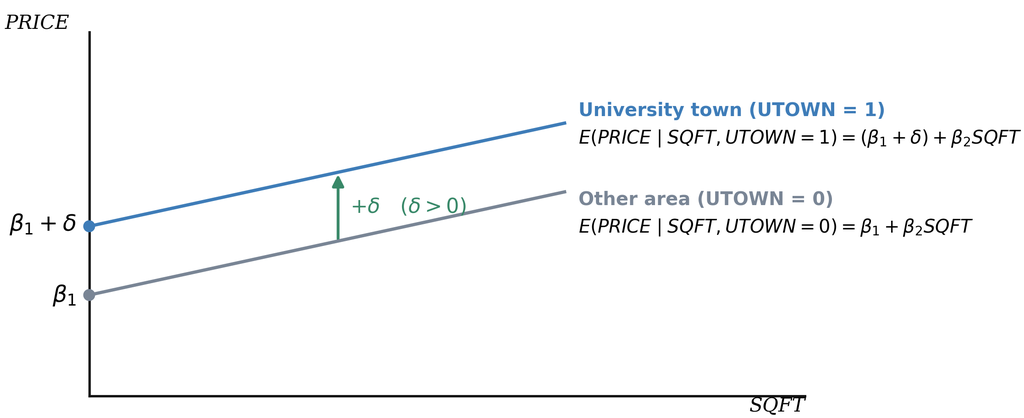

What changed? Only the intercept.

The two regression lines have the same slope, but differ vertically by δ.

## What does $\delta$ measure?

**Two houses. Same size. Different locations.**

$$E(PRICE\mid SQFT,UTOWN=1)
-
E(PRICE\mid SQFT,UTOWN=0)$$

**What remains after subtracting?**

A. $\beta_1$  
B. $\beta_2$  
C. $\delta$  
D. $\beta_2+\delta$

$$\boxed{\delta}$$

**$\delta$ is the expected price difference between the two locations, holding house size fixed.**

This is the **location premium** (if $\delta>0$).

## Who is our reference group?

### 🏠 Other area

**UTOWN = 0**

**Reference group**

### 🏠 Near university

**UTOWN = 1**

Comparison group

The group coded **0** is the **reference group** (or *base group*).

We compare the group coded **1** against this reference group, holding SQFT fixed.

## What if we reverse the coding?

$$LUTOWN=
\begin{cases}
0 & \text{if the house is near the university}\\
1 & \text{otherwise}
\end{cases}$$

$$PRICE=\alpha_1+\beta_2SQFT+\lambda LUTOWN+e$$

**Question:**

What happens when `LUTOWN = 0`?

What happens when `LUTOWN = 1`?

Which group is now the reference group?

## What does the new coding imply?

### 🏠 University town: `LUTOWN = 0`

$$E(PRICE \mid SQFT, LUTOWN=0)=\alpha_1+\beta_2SQFT$$

### 🏠 Other area: `LUTOWN = 1`

$$E(PRICE \mid SQFT, LUTOWN=1)=(\alpha_1+\lambda)+\beta_2SQFT$$

**What changed?**

The reference group is now **University town**.

**Same predictions. Different reference group.**

## What does this look like?

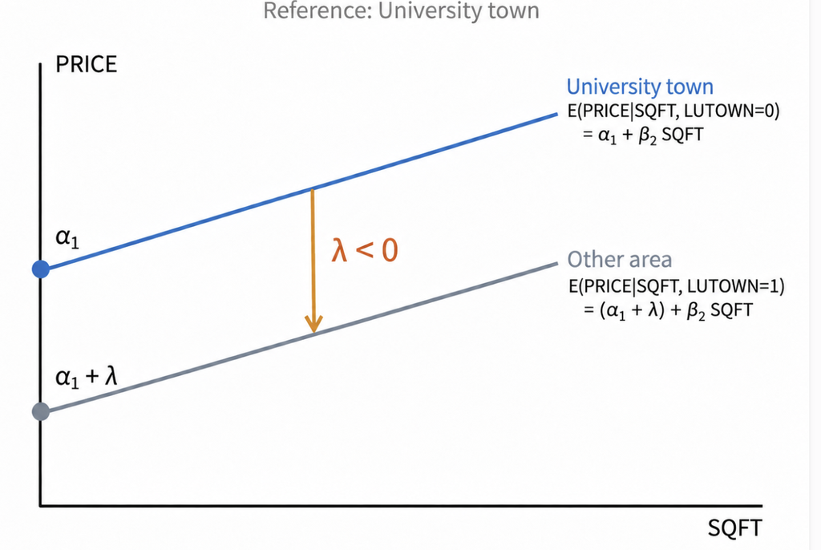

## Same two lines. Different reference groups.

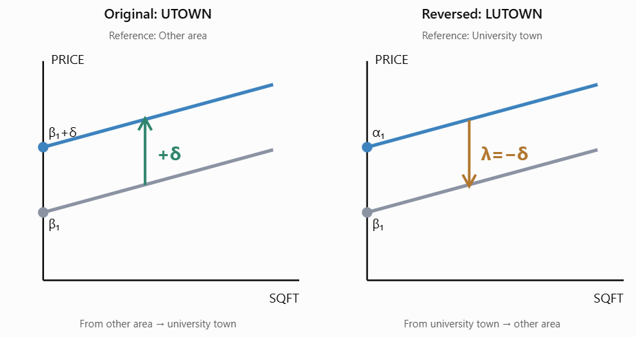

Same lines. Same predicted prices. Different reference groups.

## Can we include both indicators?

$$PRICE=\beta_1+\beta_2SQFT+\delta UTOWN+\lambda LUTOWN+e$$

| Location | UTOWN | LUTOWN | Sum |
| --- | --- | --- | --- |
| Near university | 1 | 0 | 1 |
| Other area | 0 | 1 | 1 |

$$UTOWN+LUTOWN=1$$

**Question:** What is special about this relationship?

## The dummy variable trap

$$UTOWN+LUTOWN=1$$

But the intercept already contains a **constant 1**.

$$1=UTOWN+LUTOWN$$

**Problem:** Perfect multicollinearity.

We cannot separately estimate all three coefficients.

**Solution:** With an intercept, include only **one location indicator**.

## Your turn: What do the numbers tell us?

Suppose we estimate:

$$\widehat{PRICE}=25+7.6SQFT+20UTOWN$$

Both houses have **2,000 square feet**.

**Questions:**

- What is the predicted price of House B?
- What is the predicted price of House A?
- What is the estimated location premium?

$$\begin{aligned}
\widehat{PRICE}_B &=25+7.6(20)=177\\
\widehat{PRICE}_A &=25+7.6(20)+20=197
\end{aligned}$$

**Location premium = $20,000.**

## What have we learned?

$$PRICE=\beta_1+\beta_2SQFT+\delta UTOWN+e$$

- **0 or 1:** An indicator identifies which group a house belongs to.
- **Intercept shift:** $\delta$ measures the expected price difference, holding SQFT fixed.
- **Reference group:** The group coded 0 is our starting point.
- **Reverse the coding:** The interpretation changes, but predicted prices do not.
- **Avoid the trap:** With an intercept and two groups, include only one indicator.

## Can location change the slope?

**Our new model:**

$$PRICE=\beta_1+\beta_2SQFT+\gamma(SQFT\times UTOWN)+e$$

**Other area: UTOWN = 0**

$$E(PRICE\mid SQFT,UTOWN=0)=\beta_1+\beta_2SQFT$$

**University town: UTOWN = 1**

$$E(PRICE\mid SQFT,UTOWN=1)
=\beta_1+(\beta_2+\gamma)SQFT$$

**Question:** What stayed the same? What changed?

## What does this look like?

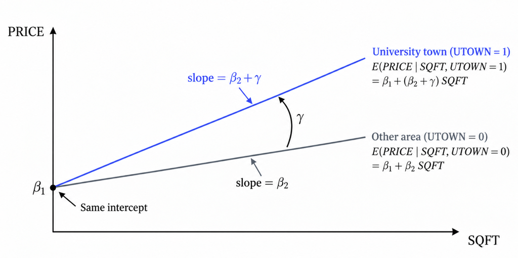

## Can location change both the intercept and slope?

**Our new model:**

$$PRICE=\beta_1+\beta_2SQFT+\delta UTOWN
+\gamma(SQFT\times UTOWN)+e$$

**🏠 Other area: UTOWN = 0**

$$E(PRICE\mid SQFT,UTOWN=0)
=\beta_1+\beta_2SQFT$$

**🏠 University town: UTOWN = 1**

$$E(PRICE\mid SQFT,UTOWN=1)
=(\beta_1+\delta)+(\beta_2+\gamma)SQFT$$

**Question:** What changed this time?

## What does this look like?

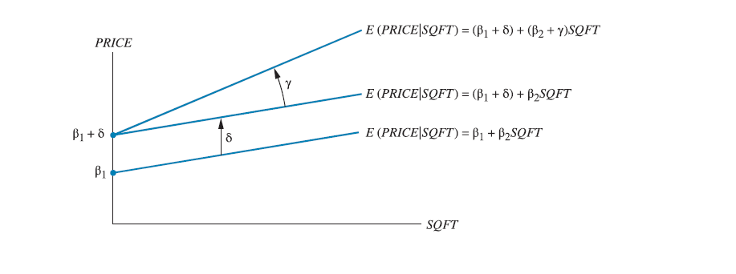

## Your turn: Estimate & answer the questions in the next slide

### Model A

$$PRICE=\beta_1+\beta_2SQFT+e$$

### Model B

$$PRICE=\beta_1+\beta_2SQFT+\delta\ UTOWN+e$$

Location changes intercept.

### Model C

$$PRICE=\beta_1+\beta_2SQFT+\gamma (SQFT \times UTOWN)+e$$

Location changes slope.

### Model D

$$PRICE=\beta_1+\beta_2SQFT+\delta UTOWN+\gamma(SQFT\times UTOWN)+e$$

## The tasks

For **each model**, the goal is to answer:

1. How do we estimate it in R?
2. What do the estimated coefficients mean?
3. What is the **marginal effect** of price w.r.t. house size?
4. What is the **elasticity** of house price w.r.t house size?

Then we compare all four models.